# Plotting assignment #2

- Show All Code
- Hide All Code
- View Source

Labels, Geoms, and Filters

Author

Haley Brumberger

Published

February 9, 2026

# 1 Setup

Using R version 4.5.2 (2025-10-31) , R Core Team (2022), and ggplot2 version 4.0.0 from the tidyverse (Wickham et al. 2019).

```r
# load packages
library(ggplot2)
library(dplyr)
library(readr)
# load script files
```

# 2 Data

```r
# load lemur data and set show_col_types to false to suppress the message in the html
lemurs <- read_csv(
  "https://raw.githubusercontent.com/rfordatascience/tidytuesday/master/data/2021/2021-08-24/lemur_data.csv",
  show_col_types = FALSE
)

#make smaller dataset with only adult lemur data and fewer columns of interest, filtering so that only adult lemurs are included.
adult_lemurs <- lemurs |>
  filter(age_category == "adult") |>
  select(
    name,
    sex,
    dob,
    birth_month,
    dod,
    age_at_death_y,
    age_max_live_or_dead_y,
    n_known_offspring,
    age_at_wt_y,
    weight_g
  )
```

# 3 Lemur Plots

## 3.1 Lemur Weight Comparison Between Sexes

Figure 1 is a boxplot showing the distribution of lemur weights in grams in female (pink) and male (blue) lemurs. The median (center line), interquartile range (box size), and spread (whiskers) of female lemur weights are similar to those of male lemur weights. The data are not very symmetric about the median: the upper quartiles in both the female and male data have a larger spread than any of the other quartiles. The biggest difference between the two sexes is that the female lemur outlier points are significantly higher. Upon digging through the data, it looks like a lemur named “Sabina” weighed in multiple times between 6,000-10,000 grams between 1989 and 1991. According to Duke’s website, she was put on a diet in 1991 and slimmed down.

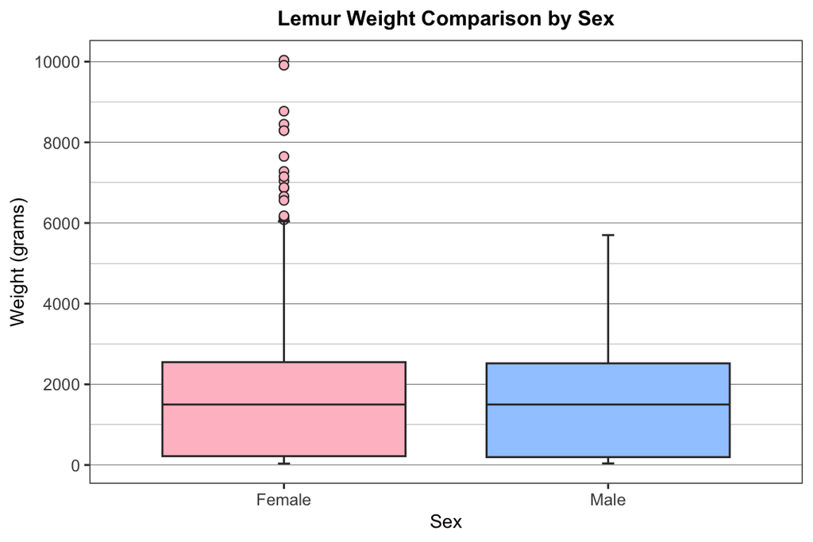

Figure 1: A boxplot comparing lemur weights in grams, separated by sex. Note the outlier–a lemur named Sabina at the Duke Lemur Center, who was overweight (twice the size of a typical lemur of her species!) between 1989-1991.

```r
adult_lemurs |>
  ggplot() +
  aes(x = sex, y = weight_g, fill = sex) + #mapping variables such that the x axis and colors are separated by sex and the y axis shows weight in grams
  theme_bw() + #setting a base theme to get rid of grey plot background
  geom_boxplot(
    median.linewidth = 0.5, #setting line widths to be consistent
    staplewidth = 0.05,
    outlier.shape = 21, #setting the shape to be a fillable circle so a black outline around each point is present, which makes it easier to see individual points
    outlier.size = 2, #setting point size to be bigger
    outlier.fill = "pink"
  ) + #setting point color for outliers
  scale_fill_manual(values = c("F" = "pink", "M" = "#a0cbffff")) + #manually setting colors for the boxes, females are pink while males are blue.
  labs(
    x = "Sex", #changing the x axis label to have a capital "S"
    y = "Weight (grams)", #labeling the y axis
    title = "Lemur Weight Comparison by Sex"
  ) +
  scale_x_discrete(labels = c("Female", "Male")) + #setting the axis values to be full words instead of just letters ("Female" and "Male" vs. "F" and "M")
  scale_y_continuous(breaks = seq(0, 10000, 2000)) + #setting the y axis between 0 and 10,000 with steps every 2,000--this also results in more major tick marks than the default setting and makes the plot easier to read/evaluate
  theme(
    plot.title = element_text(size = 11, face = "bold", hjust = 0.5), #enlarging, bolding, and centering the plot title
    legend.position = "none", #getting rid of the legend since the labels are straightforward
    panel.grid.major.y = element_line(color = "black", linewidth = 0.1), #setting the y axis grid to have wider major lines than minor lines
    panel.grid.minor.y = element_line(color = "black", linewidth = 0.05),
    panel.grid.major.x = element_blank(), #getting rid of the x axis grid since there are only two options and they are separated by enough space (the line was distracting)
    axis.title = element_text(size = 10) #setting axis size
  )
```

## 3.2 Lemur Age vs. Weight

Figure 2 is a scatterplot showing lemur age in years vs. weight in grams, with colors separated by sex and a line of best fit with a non-linear formula superimposed on top for each sex (red is female, blue is male). This plot depicts individuals more than once–in other words, most lemurs were weighed more than once, and each weight/date combination is represented by a point on the plot. Again, the outlier (Sabina) is shown as the points between 6,000-10,000 grams, while a majority of the lemur weights are below 4,000 grams. The lines of best fit for each sex are similar, with the male (blue) line extending slightly further out and up to the right of the plot, indicating that the oldest lemur weighed was a male. The lines also indicate that the fastest weight gain (a.k.a., the steepest slope) occurs between 0-5 years, and then weight increases slowly until death.

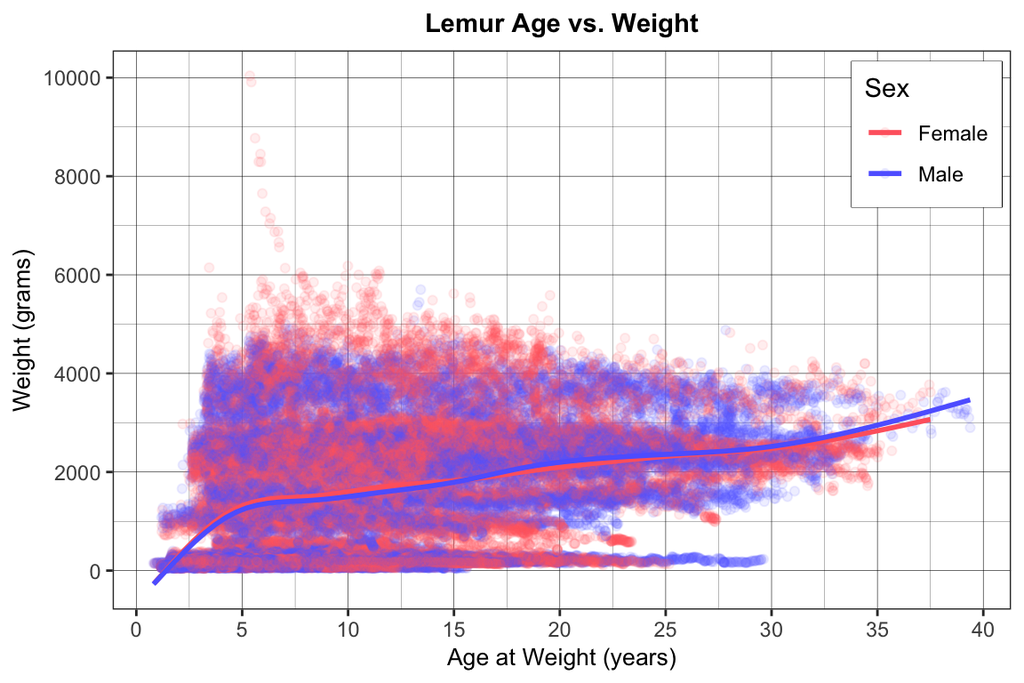

Figure 2: A scatterplot showing lemur ages vs weights, with colors indicating sex (red = female; blue = male). Many individuals are weighed more than once, with each data point representing a specific combination of date + weight.

```r
adult_lemurs |>
  ggplot() +
  aes(x = age_at_wt_y, y = weight_g, color = sex) + #mapping variables
  geom_point(alpha = 0.1) + #plotting points and setting transparency (10% opaque, so very transparent, for ease of seeing points and patterns)
  scale_color_manual(
    values = c(F = "#ff666eff", M = "#6068ffff"),
    labels = (c(F = "Female", M = "Male"))
  ) + #manually setting the colors to be red and blue for female and male, respectively, and changing the labels so they are full words instead of letters
  geom_smooth(se = FALSE) + #adding a line of best fit and taking away the standard error cloud
  theme_bw() + #setting a base theme
  labs(
    #adding x, y, legend (color), and title labels
    x = "Age at Weight (years)",
    y = "Weight (grams)",
    title = "Lemur Age vs. Weight",
    color = "Sex"
  ) +
  scale_y_continuous(breaks = seq(0, 10000, 2000)) + #setting the y scale to be from 0-10,000 in steps of 2,000--makes the plot more legible
  scale_x_continuous(breaks = seq(0, 40, 5)) + #setting the x scale to be from 0-40 with major axis ticks every 5 years to make the data more legible
  theme(
    plot.title = element_text(size = 11, face = "bold", hjust = 0.5), #enlarging, bolding, and centering title
    panel.grid.major.y = element_line(color = "black", linewidth = 0.1), #making line widths for the grid bigger for the major ticks and smaller for the minor ticks
    panel.grid.minor.y = element_line(color = "black", linewidth = 0.05),
    panel.grid.major.x = element_line(color = "black", linewidth = 0.1),
    panel.grid.minor.x = element_line(color = "black", linewidth = 0.05),
    axis.title = element_text(size = 10), #setting axes title text size
    legend.position = "inside", #moving the legend to inside of the plot
    legend.position.inside = c(0.99, 0.98), #setting the legend position in reference to the line below
    legend.justification = c("right", "top"), #reference frame for setting the legend position
    legend.box.background = element_rect(
      color = "black",
      fill = "white",
      linewidth = 0.25
    ) #setting the legend to have a white background and a black outline,
  )
```

## 3.3 Lemurs Born in Each Month

Figure 3 is a bar plot showing how many lemurs were born in each month. Because the lemurs are almost all counted more than once (e.g., each lemur has multiple rows in the dataset due to multiple weigh-ins), this data is likely not perfectly representative of the actual distribution of lemur births. Regardless, the plot shows that March and April likely have the highest birth rates, with ~800 more lemurs born in March than the next highest month (July), and still ~700 more born in April than in March. This plot suggests that September has the least amount of births, closely followed by November. The colors serve simply to separate each month visually.

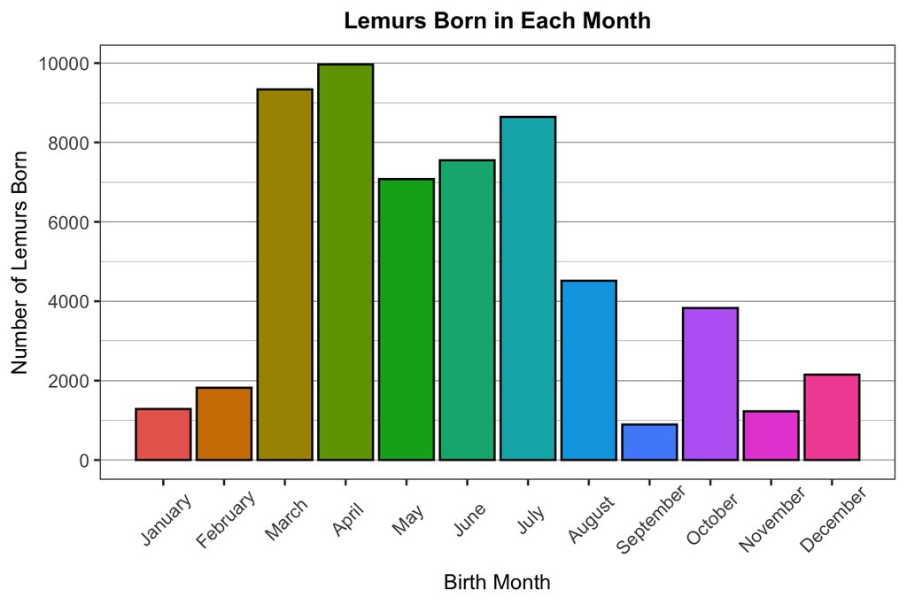

Figure 3: A bar plot illustrating how many lemurs were born in each month. Note that–as in the previous plots–most lemurs are counted more than once (due to multiple weighings), artificially and unevenly inflating the numbers of lemurs born in each month.

```r
adult_lemurs |>
  ggplot() +
  aes(x = birth_month, fill = factor(birth_month)) + #mapping the variables and using factor() to make codes for each unique birth month entry so that scale_fill can be used below
  theme_bw() + #setting base theme
  geom_bar(color = "black") + #setting the outline color for the bars
  labs(
    x = "Birth Month", #x axis label
    y = "Number of Lemurs Born", #y axis label
    title = "Lemurs Born in Each Month"
  ) + #plot title
  scale_y_continuous(breaks = seq(0, 10000, 2000)) + #setting the y scale between 0-10,000 so that there are major breaks every 2,000
  scale_x_continuous(
    breaks = c(1:12),
    labels = c(
      "January",
      "February",
      "March",
      "April",
      "May",
      "June",
      "July",
      "August",
      "September",
      "October",
      "November",
      "December"
    )
  ) + #setting the x axis to change the numbers in the dataset (1.00-12.00) into the months of the year they represent
  scale_fill_hue(c = 100, l = 60) + #setting the colors of the bars--this maps each level to an evenly spaced hue on the color wheel, where c is chroma (intensity of color between 0-360) and l is luminence (lightness between 0-100)
  guides(fill = "none") + #getting rid of the legend since the colors just serve as a visual way to separate each month
  theme(
    plot.title = element_text(size = 11, face = "bold", hjust = 0.5), #enlarging, bolding, centering the title
    panel.grid.major.y = element_line(color = "black", linewidth = 0.1),
    panel.grid.minor.y = element_line(color = "black", linewidth = 0.05),
    panel.grid.major.x = element_blank(), #getting rid of x axis lines because the vertical lines are distracting and unnecessary in a box plot (also below)
    panel.grid.minor.x = element_blank(),
    axis.title = element_text(size = 10), #setting axis text size
    axis.text.x = element_text(angle = 45, vjust = 0.65)
  ) #rotating and adjusting the vertical position of x axis scale labels so longer entries can be seen in full
```

# 4 References

R Core Team. 2022. *R: A Language and Environment for Statistical Computing*. Vienna, Austria: R Foundation for Statistical Computing. https://www.R-project.org/.

Wickham, Hadley, Mara Averick, Jennifer Bryan, Winston Chang, Lucy D’Agostino McGowan, Romain François, Garrett Grolemund, et al. 2019. “Welcome to the tidyverse.” *Journal of Open Source Software* 4 (43): 1686. https://doi.org/10.21105/joss.01686.